# Lab-3.1 MNIST

In this lab we perform multi-class classification with a CNN using `PyTorch` **AND** `Keras`.

**Submission:**

- You need to upload TWO documents to Canvas when you are done
  - 1. A PDF (or HTML) of the completed form of the completed `MNIST.ipynb` notebook (MNIST in Keras)
  - 1. A PDF (or HTML) of the completed form of the completed `CIFAR.ipynb` notebook (CIFAR in PyTorch)
- The final uploaded version should NOT have any code-errors present
- All outputs must be visible in the uploaded version, including code-cell outputs, images, graphs, etc

**Instructions**

- Code Multi-class classification using LeNet type architecture CNN to train
  - 1. MNIST training with Keras, in `MNIST.ipynb`.
  - 2. CIFAR training with PyTorch, in `CIFAR.ipynb`.
  - **If you use an online reference, please cite the source and don’t copy more than a few lines of code**
  - Normalize the data as needed
  - Visualize the results at the end where possible
  - Partition data into training, validation, and test
  - Monitor training and validation throughout training by plotting
  - For the final fit, report the confusion matrix at the end
  - Print training, validation, and test errors at the very end
  - You `MUST` use early stopping:
  - Do basic `MANUAL` hyper-parameter tuning to try to achieve an optimal fit model
    - i.e. best training/validation loss without over-fitting
    - Explore L1 and L2 regularization and dropout
    - Explore different optimizers
    - Use the loss functions specified in the textbook
    - Explore different options for activation functions, network size/depth, etc
- **Document what is going on in the code, as needed, with narrative markdown text between cells.**
- *Submit the version with hyper parameters that provide the optimal fit*
  - i.e. you don’t need to show the outputs of your hyper-parameter tuning process

# Imports

```python
import numpy as np
import matplotlib.pyplot as plt
from keras.models import Sequential
from keras.layers import Conv2D, MaxPooling2D, Flatten, Dense, Dropout
from keras.datasets import mnist
from tensorflow.keras.utils import to_categorical
from keras.callbacks import EarlyStopping

import torch
import torchvision
import torchvision.transforms as transforms
from torch.utils.data.sampler import SubsetRandomSampler
import torch.nn as nn
import torch.optim as optim
import torch.nn.functional as F
from torch.utils.data import DataLoader, random_split
from torchvision import datasets, transforms
from sklearn.metrics import confusion_matrix
import itertools
import seaborn as sns
```

[output not shown]

# Data for MNIST

```python
#load MNIST
(x_train, y_train), (x_test, y_test) = mnist.load_data()

#normalize
x_train = x_train.astype('float32') / 255.0
x_test = x_test.astype('float32') / 255.0

#reshape for the CNN input and one-hot encode the labels
x_train = x_train.reshape(x_train.shape[0], 28, 28, 1)
x_test = x_test.reshape(x_test.shape[0], 28, 28, 1)
y_train = to_categorical(y_train, 10)
y_test = to_categorical(y_test, 10)
```

# Build Model

```python
model = Sequential()
model.add(Conv2D(32, kernel_size=(3, 3), activation='relu', input_shape=(28, 28, 1)))
model.add(MaxPooling2D(pool_size=(2, 2)))
model.add(Conv2D(64, (3, 3), activation='relu'))
model.add(MaxPooling2D(pool_size=(2, 2)))
model.add(Flatten())
model.add(Dense(128, activation='relu'))
model.add(Dropout(0.5))
model.add(Dense(10, activation='softmax'))
```

[output not shown]

# Compile

```python
model.compile(loss='categorical_crossentropy', optimizer='adam', metrics=['accuracy'])

#define early stopping
early_stopping = EarlyStopping(monitor='val_loss', patience=3)
```

[output not shown]

# Train the Model

```python
history = model.fit(x_train, y_train, batch_size=128, epochs=30, validation_split=0.2, verbose=2, callbacks=[early_stopping])
```

```
WARNING:tensorflow:From C:\Users\lando\AppData\Local\Programs\Python\Python311\Lib\site-packages\keras\src\utils\tf_utils.py:492: The name tf.ragged.RaggedTensorValue is deprecated. Please use tf.compat.v1.ragged.RaggedTensorValue instead.

WARNING:tensorflow:From C:\Users\lando\AppData\Local\Programs\Python\Python311\Lib\site-packages\keras\src\engine\base_layer_utils.py:384: The name tf.executing_eagerly_outside_functions is deprecated. Please use tf.compat.v1.executing_eagerly_outside_functions instead.

375/375 - 2s - loss: 0.3516 - accuracy: 0.8908 - val_loss: 0.0749 - val_accuracy: 0.9783 - 2s/epoch - 6ms/step
375/375 - 2s - loss: 0.1094 - accuracy: 0.9671 - val_loss: 0.0605 - val_accuracy: 0.9829 - 2s/epoch - 5ms/step
375/375 - 2s - loss: 0.0798 - accuracy: 0.9764 - val_loss: 0.0455 - val_accuracy: 0.9858 - 2s/epoch - 5ms/step
375/375 - 2s - loss: 0.0647 - accuracy: 0.9809 - val_loss: 0.0449 - val_accuracy: 0.9869 - 2s/epoch - 5ms/step
375/375 - 2s - loss: 0.0571 - accuracy: 0.9827 - val_loss: 0.0397 - val_accuracy: 0.9887 - 2s/epoch - 5ms/step
375/375 - 2s - loss: 0.0466 - accuracy: 0.9857 - val_loss: 0.0375 - val_accuracy: 0.9903 - 2s/epoch - 5ms/step
375/375 - 2s - loss: 0.0418 - accuracy: 0.9872 - val_loss: 0.0389 - val_accuracy: 0.9893 - 2s/epoch - 5ms/step
375/375 - 2s - loss: 0.0379 - accuracy: 0.9883 - val_loss: 0.0369 - val_accuracy: 0.9896 - 2s/epoch - 5ms/step
375/375 - 2s - loss: 0.0328 - accuracy: 0.9901 - val_loss: 0.0364 - val_accuracy: 0.9910 - 2s/epoch - 5ms/step
375/375 - 2s - loss: 0.0302 - accuracy: 0.9907 - val_loss: 0.0327 - val_accuracy: 0.9912 - 2s/epoch - 5ms/step
375/375 - 2s - loss: 0.0297 - accuracy: 0.9908 - val_loss: 0.0350 - val_accuracy: 0.9908 - 2s/epoch - 5ms/step
375/375 - 2s - loss: 0.0248 - accuracy: 0.9919 - val_loss: 0.0364 - val_accuracy: 0.9908 - 2s/epoch - 5ms/step
375/375 - 2s - loss: 0.0227 - accuracy: 0.9924 - val_loss: 0.0397 - val_accuracy: 0.9907 - 2s/epoch - 5ms/step
```

# Model Eval

```
Test accuracy: 0.992900013923645
```

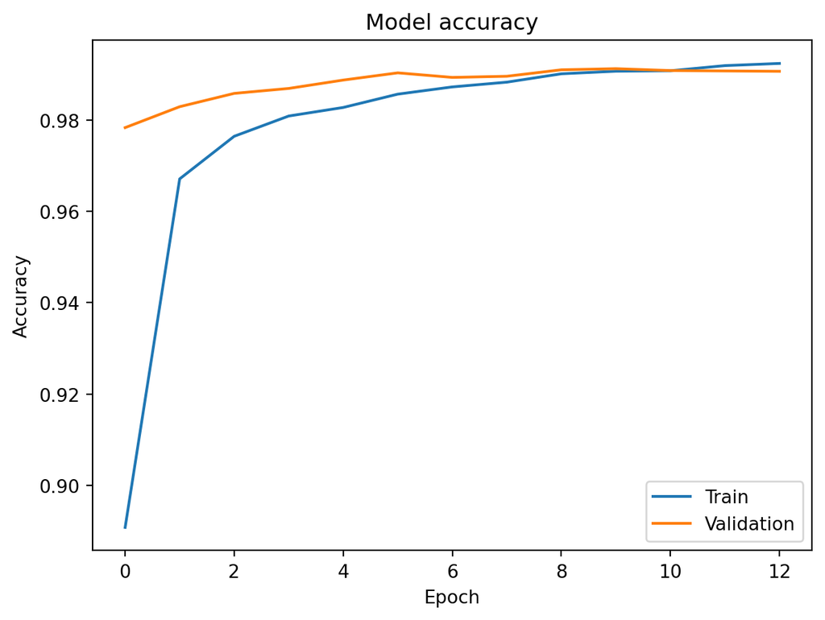

```python
#evaluate on test data
test_loss, test_acc = model.evaluate(x_test, y_test)
print('Test accuracy:', test_acc)

#plot training history
plt.plot(history.history['accuracy'])
plt.plot(history.history['val_accuracy'])
plt.title('Model accuracy')
plt.ylabel('Accuracy')
plt.xlabel('Epoch')
plt.legend(['Train', 'Validation'], loc='lower right')
plt.show()
```